# data freesort_minus_causals

Joseph Outa

2025-05-10

```r
library(codebook)
```

```r
knit_by_pkgdown <- !is.null(knitr::opts_chunk$get("fig.retina"))
knitr::opts_chunk$set(
  warning = TRUE, # show warnings during codebook generation
  message = TRUE, # show messages during codebook generation
  error = TRUE, # do not interrupt codebook generation in case of errors,
                # TRUE is usually better for debugging
  echo = TRUE  # show R code
)

library(pacman)
pacman::p_load(tidyverse, here, codebook)
ggplot2::theme_set(ggplot2::theme_bw())
```

[output not shown]

```r
codebook::codebook(d)
```

```
## No missing values.
```

### 0.1 Metadata

#### 0.1.1 Description

**Dataset name**: Dataset containing freesort minus causal pairs scores from Study 1, to be used for selecting items for Study 2

This data set was generated by the experiment1_analysis.Rmd script. There are 210 rows, corresponding to the 210 possible item pairs. There are 7 columns containing the items (first item in the pair, second item in the pair), their domains, item-pair-averaged freesort and causal distances, and the freesort minud causal distance. The latter is the measure used to select items for study 2.

**Metadata for search engines**

| name | value |
| --- | --- |
| keywords | itemA, itemB, domain_itemA, domain_itemB, mean_causal_pairs_distance, mean_freesort_distance, freesort_minus_causal |

## 1 Variables

### 1.1 itemA

The first item among item pairs in the study 1 Causal Pairs Task, which acts as the `cause` item

#### 1.1.1 Distribution

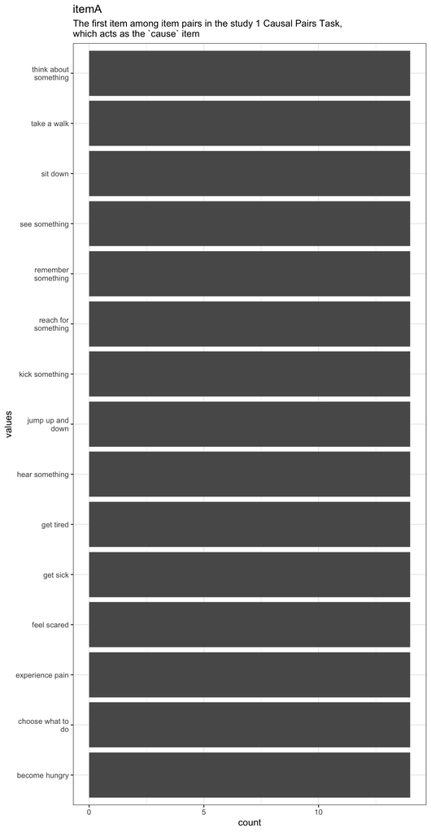

Figure 1: Distribution of values for itemA

0 missing values.

#### 1.1.2 Summary statistics

| name | label | data_type | n_missing | complete_rate | n_unique | empty | min | max | whitespace |
| --- | --- | --- | --- | --- | --- | --- | --- | --- | --- |
| itemA | The first item among item pairs in the study 1 Causal Pairs Task, which acts as the `cause` item | character | 0 | 1 | 15 | 0 | 8 | 21 | 0 |

### 1.2 itemB

#### 1.2.1 Distribution

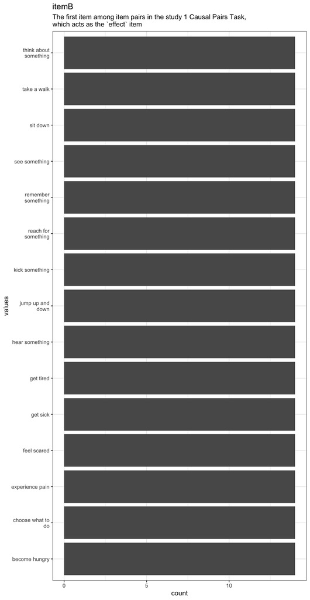

Figure 2: Distribution of values for itemB

0 missing values.

#### 1.2.2 Summary statistics

| name | label | data_type | n_missing | complete_rate | n_unique | empty | min | max | whitespace |
| --- | --- | --- | --- | --- | --- | --- | --- | --- | --- |
| itemB | The first item among item pairs in the study 1 Causal Pairs Task, which acts as the `effect` item | character | 0 | 1 | 15 | 0 | 8 | 21 | 0 |

### 1.3 domain_itemA

The domain of the first item in the pair, per RSA results of study 1

#### 1.3.1 Distribution

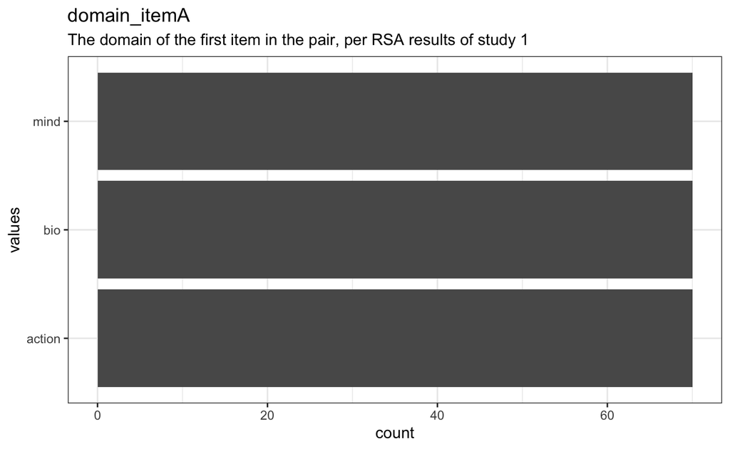

Figure 3: Distribution of values for domain_itemA

0 missing values.

#### 1.3.2 Summary statistics

| name | label | data_type | n_missing | complete_rate | n_unique | empty | min | max | whitespace |
| --- | --- | --- | --- | --- | --- | --- | --- | --- | --- |
| domain_itemA | The domain of the first item in the pair, per RSA results of study 1 | character | 0 | 1 | 3 | 0 | 3 | 6 | 0 |

### 1.4 domain_itemB

The domain of the second item in the pair, per RSA results of study 1

#### 1.4.1 Distribution

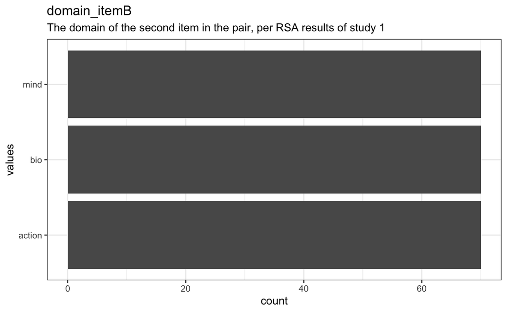

Figure 4: Distribution of values for domain_itemB

0 missing values.

#### 1.4.2 Summary statistics

| name | label | data_type | n_missing | complete_rate | n_unique | empty | min | max | whitespace |
| --- | --- | --- | --- | --- | --- | --- | --- | --- | --- |
| domain_itemB | The domain of the second item in the pair, per RSA results of study 1 | character | 0 | 1 | 3 | 0 | 3 | 6 | 0 |

### 1.5 mean_causal_pairs_distance

The mean causal distance between item A and item B

#### 1.5.1 Distribution

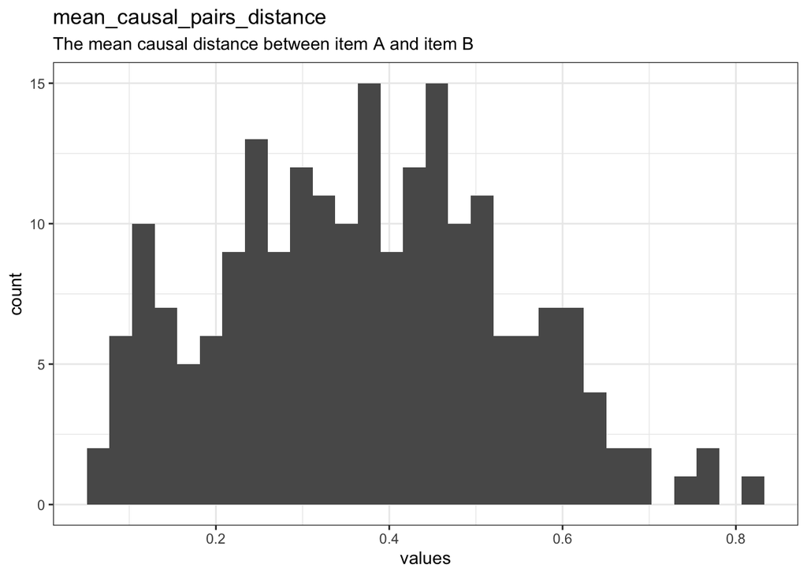

Figure 5: Distribution of values for mean_causal_pairs_distance

0 missing values.

#### 1.5.2 Summary statistics

| name | label | data_type | n_missing | complete_rate | min | median | max | mean | sd | hist |
| --- | --- | --- | --- | --- | --- | --- | --- | --- | --- | --- |
| mean_causal_pairs_distance | The mean causal distance between item A and item B | numeric | 0 | 1 | 0.064 | 0.37 | 0.82 | 0.3723324 | 0.1620221 | ▅▇▇▃▁ |

### 1.6 mean_freesort_distance

The mean freesort distance between item A and item B

#### 1.6.1 Distribution

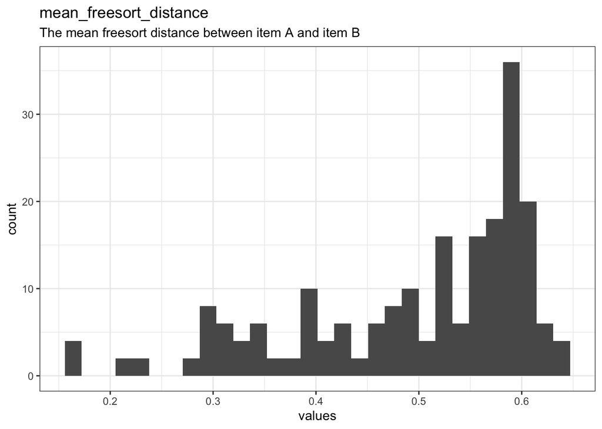

Figure 6: Distribution of values for mean_freesort_distance

0 missing values.

#### 1.6.2 Summary statistics

| name | label | data_type | n_missing | complete_rate | min | median | max | mean | sd | hist |
| --- | --- | --- | --- | --- | --- | --- | --- | --- | --- | --- |
| mean_freesort_distance | The mean freesort distance between item A and item B | numeric | 0 | 1 | 0.16 | 0.54 | 0.64 | 0.4957143 | 0.1151441 | ▁▂▂▃▇ |

### 1.7 freesort_minus_causal

The difference between the freesort distance and the causal distance

#### 1.7.1 Distribution

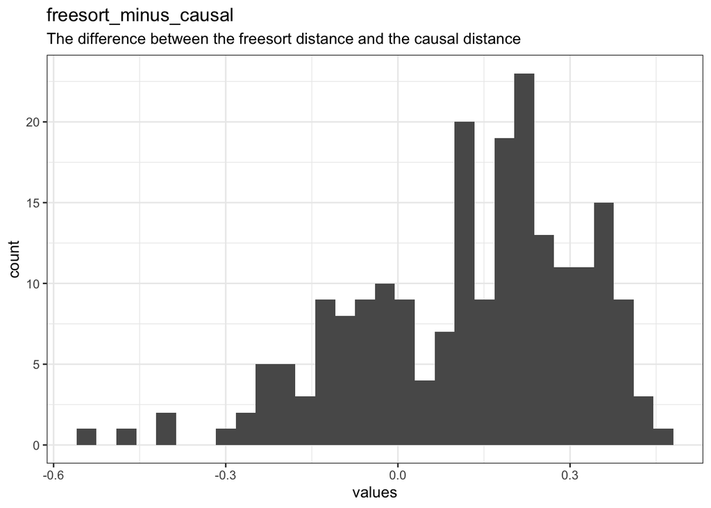

Figure 7: Distribution of values for freesort_minus_causal

0 missing values.

#### 1.7.2 Summary statistics

| name | label | data_type | n_missing | complete_rate | min | median | max | mean | sd | hist |
| --- | --- | --- | --- | --- | --- | --- | --- | --- | --- | --- |
| freesort_minus_causal | The difference between the freesort distance and the causal distance | numeric | 0 | 1 | -0.54 | 0.17 | 0.46 | 0.1233819 | 0.1942412 | ▁▂▅▇▅ |